# Analysis

Amanda Zacharias

2/9/2021

#Project Info

**Date**: February 9th, 2021 **GitHub Repository Link**: https://github.com/ForgetfulCow/Rentrez **Username**: ForgetfulCow

# Load package

```r
library(knitr)
library(dplyr)
```

# Load the Sequences.csv file

```r
SeqData <- read.csv("Sequences1.csv")
head(SeqData)
```

```
##                                                                                     Name
## 1 >HQ433692.1 Borrelia burgdorferi strain QLZP1 16S ribosomal RNA gene, partial sequence
## 2   >HQ433694.1 Borrelia burgdorferi strain CS4 16S ribosomal RNA gene, partial sequence
## 3  >HQ433691.1 Borrelia burgdorferi strain GL18 16S ribosomal RNA gene, partial sequence
##                                                                                                                                                                                                                                                                                                          …
## 1 AGCATGCAAGTCAAACGAGATGTAGCAATACATCTAGTGGCGAACGGGTGAGTAACGCGT…
## 2 AGCATGCAAGTCAAACGGGATGTAGCAATACATTCAGTGGCGAACGGGTGAGTAACGCGT…
## 3 AGCATGCAAGTCAAACGAGATGTAGTAATACATCTAGTGGCGAACGGGTGAGTAACGCGT…
```

# Count the number of each base pair (A,T,C,G), in each of the three sequences.

## Don’t include any characters from the header, use the nucleotide sequence only; you MIGHT use `gsub()`, `nchar()`, for loops, if/then statements

The first couple of lines of code generate empty vectors for each count of nucleotide type counts. length = num_sequences to account for variuos numbers of sequences in a dataframe (i.e. makes the code more generalizable).

The `for` loop is used to extract each sequence from the SeqData dataset and count the number of occurences of each nucleotide type. The loop iterates through each sequence.`gsub` removes every character in the sequence except the target. `nchar` sums the number of characters left. These number is stored in its respective vector of counts.

```r
# Generate vectors for each nucleotide type count
num_sequences <- length(SeqData$Sequence)
ACount <- vector(mode = "numeric", length = num_sequences)
TCount <- vector(mode = "numeric", length = num_sequences)
CCount <- vector(mode = "numeric", length = num_sequences)
GCount <- vector(mode = "numeric", length = num_sequences)

for (i in 1:length(SeqData$Sequence)){ # For every sequence
  ACount[i] <- nchar(gsub("[^A]","",SeqData$Sequence[i]))
  TCount[i] <- nchar(gsub("[^T]","",SeqData$Sequence[i]))
  CCount[i] <- nchar(gsub("[^C]","",SeqData$Sequence[i]))
  GCount[i] <- nchar(gsub("[^G]","",SeqData$Sequence[i]))
} # End of loop
```

# Print out each sequence

```r
print(SeqData$Sequence)
```

```
## [1] "AGCATGCAAGTCAAACGAGATGTAGCAATACATCTAGTGGCGAACGGGTGAGTAACGCGT…"
## [2] "AGCATGCAAGTCAAACGGGATGTAGCAATACATTCAGTGGCGAACGGGTGAGTAACGCGT…"
## [3] "AGCATGCAAGTCAAACGAGATGTAGTAATACATCTAGTGGCGAACGGGTGAGTAACGCGT…"
```

# Print out the number of each nucleotide as a table for each of the three sequences

The first line creates an empty vector that is the length of the number of sequences in the dataset.

A `for` loop is used to extract the Sequence ID from the name of each sequence in the dataset. Assumes the first character in the name is a `>` and the ID is 10 characters long. `substr()` function is used to do this extraction. I found this function [here](https://stat.ethz.ch/R-manual/R-devel/library/base/html/substr.html).

The next line creates a dataframe which each vector of ID’s and vectors of counts.

`kable()` is used to make a pretty table

```r
Seq_ID <- vector(length = num_sequences)

for (i in 1:length(SeqData$Sequence)){ # For every sequence
  Seq_ID[i] <- substr(SeqData$Name[i], 2, 11) # Extract the ID
} # End loop

BPCount <- data.frame(Seq_ID, ACount, TCount, CCount, GCount)
kable(BPCount, col.names = c("Sequence ID", "A Count", "T Count",
                             "C Count", "G Count"), align = "c")
```

| Sequence ID | A Count | T Count | C Count | G Count |
| --- | --- | --- | --- | --- |
| HQ433692.1 | 154 | 114 | 82 | 131 |
| HQ433694.1 | 155 | 114 | 81 | 131 |
| HQ433691.1 | 154 | 115 | 81 | 131 |

# Include an image of a bacteria from the internet, and a link to the Wikipedia page about Borrelia burgdorferi

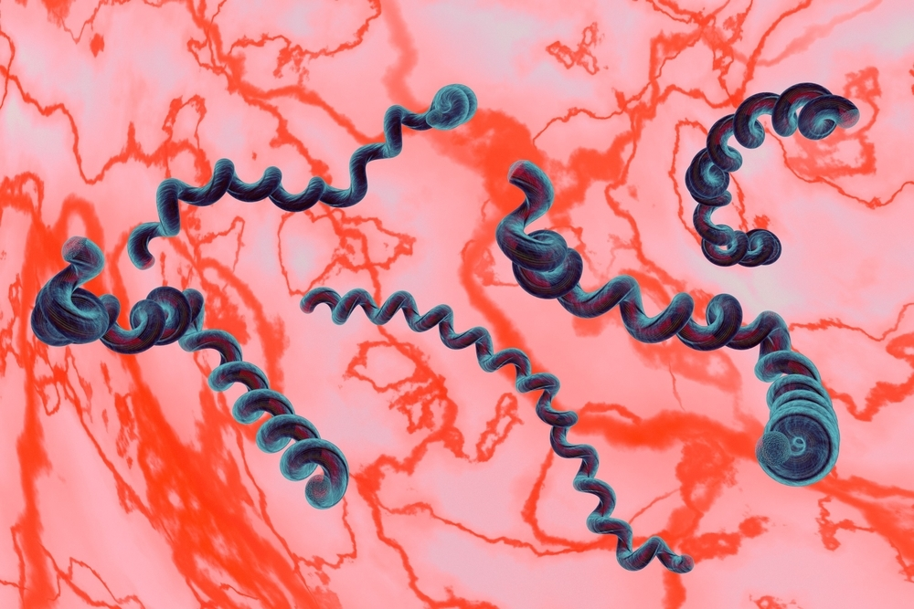

[Wikipedia page](https://en.wikipedia.org/wiki/Borrelia_burgdorferi#:~:text=Borrelia%20burgdorferi%20is%20a%20bacterial,known%20to%20cause%20the%20disease)

# Calculate the GC Content (% of nucleotides that are G or C and create a final table showing GC content for each sequence ID.

`transmute()` is used to create a new column that is the % GC Content in each sequence. This function keeps the Seq_ID variable. `round()` is used in the function to limit the number of decimals to 2.

```r
GC_Data <- transmute(BPCount,Seq_ID,
                     GC_Content = round(((CCount + GCount)/
                       (ACount + TCount + CCount + GCount))*100,
                       digits = 2))
kable(GC_Data, col.names = c("Sequence ID", "Percent GC Content"), align = "c")
```

| Sequence ID | Percent GC Content |
| --- | --- |
| HQ433692.1 | 44.28 |
| HQ433694.1 | 44.07 |
| HQ433691.1 | 44.07 |